# Find the optimum number of clusters for hierarchical clustering

Sehyun Oh

2020-12-22

# 1 Preparae negative controls

## 1.1 Build negative controls

```r
## Do not run this script without checking it first!!
source("neg_controls.R")
```

This script will execute the following processes:

1. Generate 50 synthetic datasets:
   - Each dataset contains 50 random samples from 44,890 samples (with replacement).
   - Scaramble genes in each dataset by random selection without replacement and add random value between -0.1 and 0.1
2. Row-normalize synthetic datasets
3. PCA on synthetic datasets  
   –> saved as `bootstrap_PCs_rowNorm_Neg.rds`
4. Combine top 20 PCs from traning datasets and PC1s from synthetic datasets  
   –> saved as `all_{#neg}.rds`
5. Calculate distance matrix and hcut for each combined dataset  
   –> saved as `res_dist_{#neg}.rds` and `res_hclust_{#neg}.rds`
6. Evaluate how the negative controls were separated  
   –> saved as `evals_{#neg}.rds` and `eval_summary_{#neg}.rds`

## 1.2 Validate negative controls

Below is the summary of the distance matrix of 10,720 PCs (top 20 PCs from 536 studies). We want to create a synthetic dataset as a negative control with the distance rangeing median or higher.

```r
summary(res_dist)
```

```
##    Min. 1st Qu.  Median    Mean 3rd Qu.    Max.
## 0.01688 0.98783 1.00000 0.99999 1.01217 1.97482
```

We tested the distance matrix with 50 ‘negative controls’, generated from the `neg_controls.R` script above. Distance ranges roughly between 1st quarter and 3rd quarter of training datasets’ distance distribution.

```r
summary(res.dist.neg)
```

```
##    Min. 1st Qu.  Median    Mean 3rd Qu.    Max.
##  0.9680  0.9937  1.0000  0.9999  1.0054  1.0317
```

We plot the heatmap of distance matrix with different number of negative controls (PC1s from synthetic datasets) and confirmed that they can serve as a negative control.

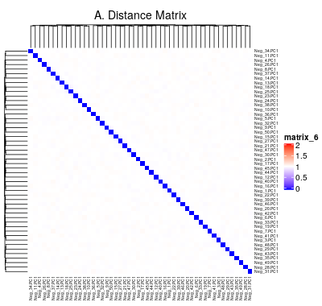

# 2 Optimum k for different numbers of controls

Next we combined top 20 PCs of training datasets and PC1s from varying numbers of negative controls (10, 20, 30, 40, and 50) and performed hierarchical clustering with different numbers of clusters. Here, we plotted the proportion of separated negative controls against the number of clusters.

Number of clusters for each combined datastes were rounds of the number of PCs divided by 9 different numbers (**d** = 7, 6, 5, 4, 3, 2.75, 2.5, 2.25, and 2).

## 2.1 Proportion of the separated negative controls

This plot shows the proportion of the negative controls that are separated under different numbers of clusters. For all five different numbers of negative controls, more than 90% of them were separated when **d = 4** and 100% of them were separated when **d = 2.25**.

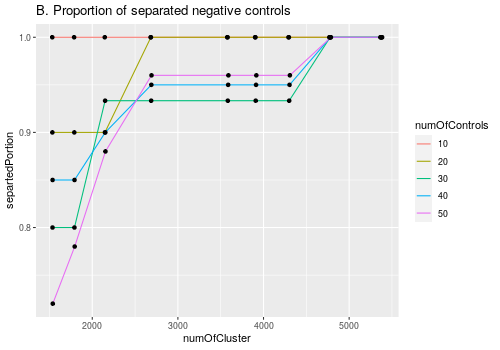

## 2.2 Number of the non-separated negative controls

This plot shows the actual number of negative controls that weren’t separated under different numbers of clusters.

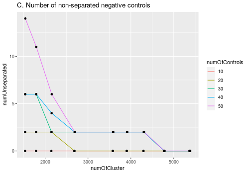